# Deliverable 2

2024-03-13

# Looking For a Data Scientist?

Dear Mr.HR Manager, I hear you are looking for a top-notch data scientist. Well, you’re in luck! In order to convince you why you should hire me, I am going to discuss one of the spookiest topics in data science: simulation error. Can we rely on data science to tell us if a roulette strategy works, or how many people in our class have the same birthday? Since I am a great data scientist, the easy answer to these questions is yes. However, I must acknowledge that all simulations are susceptible to errors. Therefore, the question is HOW large and funky the error is.

## Why am I admitting that my simualtions have errors?

It would be so much easier if I could simply say that my data models are perfect and completely reliable, but this would be a false and damaging statement. Simulations are used to predict all sorts of cooperate behaviors, such as consumer amounts and market prices. These predictions are very useful, however, it is still important to remember that simulations cannot perfectly predict human action. Following the example of consumer amounts, a simulation would fail if a tick-tock trend quickly emerged and made an activity or product trendy.

## Concepts Overview

The first two important vocabulary terms to discuss are **probability** and **estimated probability**. Probability is true the likelihood that an event occurs and is measured from 1-0, whereas estimated probability is the likelihood that we determined from our simulation and data. The second two important terms are **absolute error** and **relative error**. absolute error is the absolute value of the difference between estimated probability and probability (|p̂−p| ). It indicates how far off our estimate was from the true probability and is useful when we want to understand the accuracy of our simulation’s estimates Relative error is the absolute error divided by the probability (|p̂−p|/p). It provides an error relative to the probability so we can assess the accuracy based on the true probability, so it is useful to understand the scale at which an error inaccuracy would create damage.

## Error In Action

```r
# Step 1: calculate estimated probability, absolute error, and relative error
error_v4 <- function(r,n,p){
  d1 <- rbinom(r,n,p)
  phat <- d1/n
# absolute error = measured value - actual value
  ae <- abs(phat-p)
  re <- ae/p
  c(mean(ae), mean(re))
}

mean_error_v4 <- error_v4(5000, 128, .3)

# create vectors for probabilities and replicate numbers
ps <- c(0.01, 0.05, 0.1, 0.25, 0.5)
ns <- 2^(2:15)

# create empty vectors to store the errors
out_ae <- array(NA, dim=c(length(ps), length(ns)))
out_re <- array(NA, dim=c(length(ps), length(ns)))

# Step 2: Iterate over the sets probabilties and number of replicates
for(i in seq_along(ps)){
    for(j in seq_along(ns)){
       out <- error_v4(5000, ns[j], ps[i])
       out_ae[i,j] <- out[1]
       out_re[i,j] <- out[2]
    }
}
```

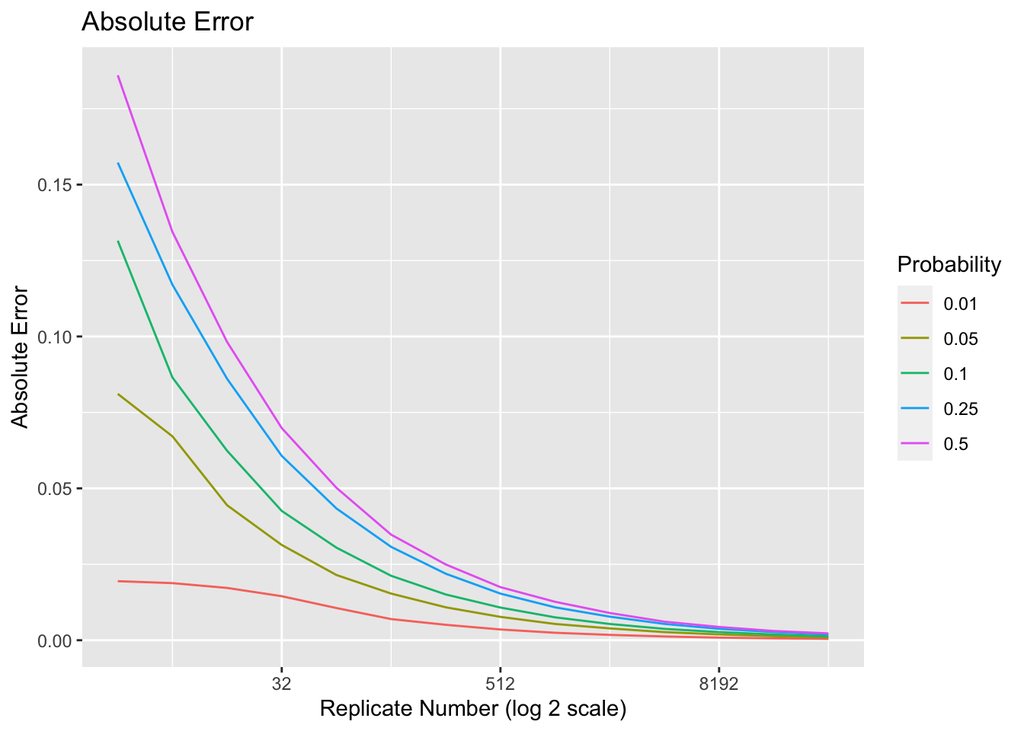

```r
# Step 3: Graph the errors

library(ggplot2)

# Plotting absolute error
df_ae <- data.frame(replicates = rep(ns, each = length(ps)),
                    absolute_error = as.vector(out_ae),
                    probabilities = rep(ps, length(ns)))

ggplot(df_ae, aes(x = replicates, y = absolute_error, color = as.factor(probabilities))) + geom_line() +  scale_x_continuous(trans = 'log2') +  labs(title = "Absolute Error", x = "Replicate Number (log 2 scale)",   y = "Absolute Error",  color = "Probability")
```

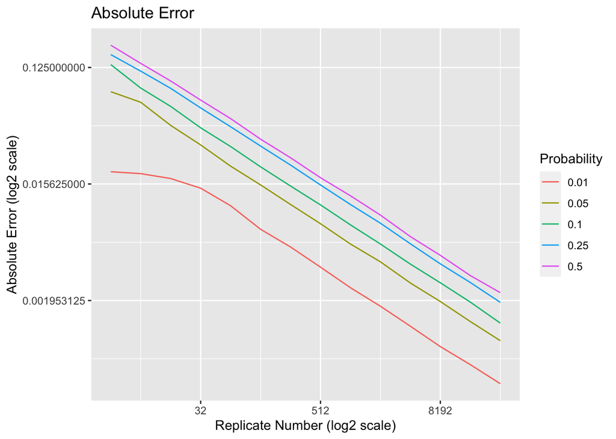

```r
ggplot(df_ae, aes(x = replicates, y = absolute_error, color = as.factor(probabilities))) + geom_line() +  scale_x_continuous(trans = 'log2') + scale_y_continuous(trans = 'log2') + labs(title = "Absolute Error", x = "Replicate Number (log2 scale)",   y = "Absolute Error (log2 scale)",  color = "Probability")
```